# Grouping and Summarizing Notebook

#### Housekeeping:

Like in the previous sections for tideverse, we will use gapminder and dplyr:

```r
library(gapminder)
library(dplyr)
library(ggplot2)
```

#### Summarize verb

`summarize()` from tidyverse allows to print variable(s) at the end of piping operations. Suppose we don’t want to print all other data except the median of a variable in that dataset.

Suppose we want to summarize the median of life expectancy which we will call medianLifeExp:

```r
gapminder %>%
  summarize(medianLifeExp = median(lifeExp))
```

| medianLifeExp |
| --- |
| 60.7125 |

#### Another practice by using other tidyverse verbs:

Task: Find both the median life expectancy (lifeExp) and the maximum GDP per capita (gdpPercap) in the year 1957, calling them medianLifeExp and maxGdpPercap respectively. You can use the `max()` function to find the maximum.

```r
gapminder %>%
  filter(year == 1957) %>%
  summarize(medianLifeExp = median(lifeExp), maxGdpPercap = max(gdpPercap))
```

| medianLifeExp | maxGdpPercap |
| --- | --- |
| 48.3605 | 113523.1 |

#### Grouping via group_by()

Suppose we want to know the median life expectancy and max GDP for each year, then we can use `group_by()` before we invoke `summarize()`. Here’s an example:

```r
gapminder %>%
  group_by(year) %>%
  summarize(medianLifeExp = median(lifeExp), maxGdpPercap = max(gdpPercap))
```

| year | medianLifeExp | maxGdpPercap |
| --- | --- | --- |
| 1952 | 45.1355 | 108382.35 |
| 1957 | 48.3605 | 113523.13 |
| 1962 | 50.8810 | 95458.11 |
| 1967 | 53.8250 | 80894.88 |
| 1972 | 56.5300 | 109347.87 |
| 1977 | 59.6720 | 59265.48 |
| 1982 | 62.4415 | 33693.18 |
| 1987 | 65.8340 | 31540.97 |
| 1992 | 67.7030 | 34932.92 |
| 1997 | 69.3940 | 41283.16 |

[output cut: 2 more lines]

As shown above, `group_by()` allowed us to partition the summarize verb results for each year that exists in our dataset.

#### Using more than one filter for group_by()

We can use more than one filter for our group verb and it will find each unique combination of both.

Suppose we want to ind the median life expectancy (lifeExp) and maximum GDP per capita (gdpPercap) within each combination of continent and year, saving them into medianLifeExp and maxGdpPercap, respectively:

```r
gapminder %>%
  group_by(continent, year) %>%
  summarize(medianLifeExp = median(lifeExp), maxGdpPercap = max(gdpPercap), dataCount = n())
```

| continent | year | medianLifeExp | maxGdpPercap | dataCount |
| --- | --- | --- | --- | --- |
| Africa | 1952 | 38.8330 | 4725.296 | 52 |
| Africa | 1957 | 40.5925 | 5487.104 | 52 |
| Africa | 1962 | 42.6305 | 6757.031 | 52 |
| Africa | 1967 | 44.6985 | 18772.752 | 52 |
| Africa | 1972 | 47.0315 | 21011.497 | 52 |
| Africa | 1977 | 49.2725 | 21951.212 | 52 |
| Africa | 1982 | 50.7560 | 17364.275 | 52 |
| Africa | 1987 | 51.6395 | 11864.408 | 52 |
| Africa | 1992 | 52.4290 | 13522.158 | 52 |
| Africa | 1997 | 52.7590 | 14722.842 | 52 |

[output cut: 50 more lines]

#### Plotting summarized and grouped data:

We can easily do this by assigning the filtered data into a variable. Then using that variable, we can plot it by passing it to `ggplot()`. Here is an example where we grouped_by the gapminder data by year and summarized both the median expectancy and maximum GDP per capita. Using the data, we plot a scatter plot where x corresponds to year and y corresponds to median life expectancy:

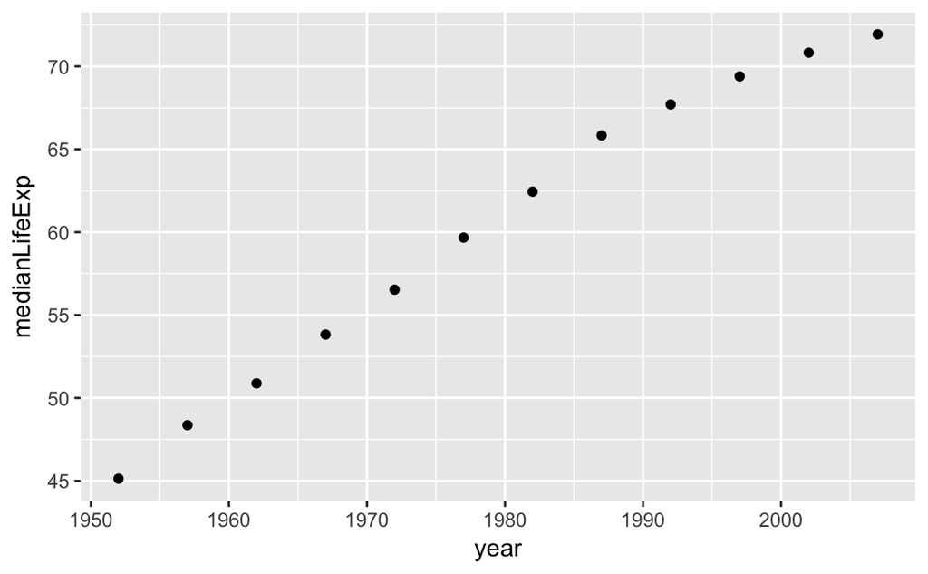

```r
by_year <- gapminder %>%
  group_by(year) %>%
  summarize(medianLifeExp = median(lifeExp),
            maxGdpPercap = max(gdpPercap))
# Create a scatter plot showing the change in medianLifeExp over time
ggplot(by_year, aes(x = year, y = medianLifeExp)) + geom_point()
```

**Note:** Do note that the year is y-scale is off and starts at y=45.

#### Fixing y-scale by adding expand_limits()

In the scatter plot above, the plot started at y=45. We can simply fix it by adding expand_limits(y=0) to the methods we invoked for ggplot. Here is an example:

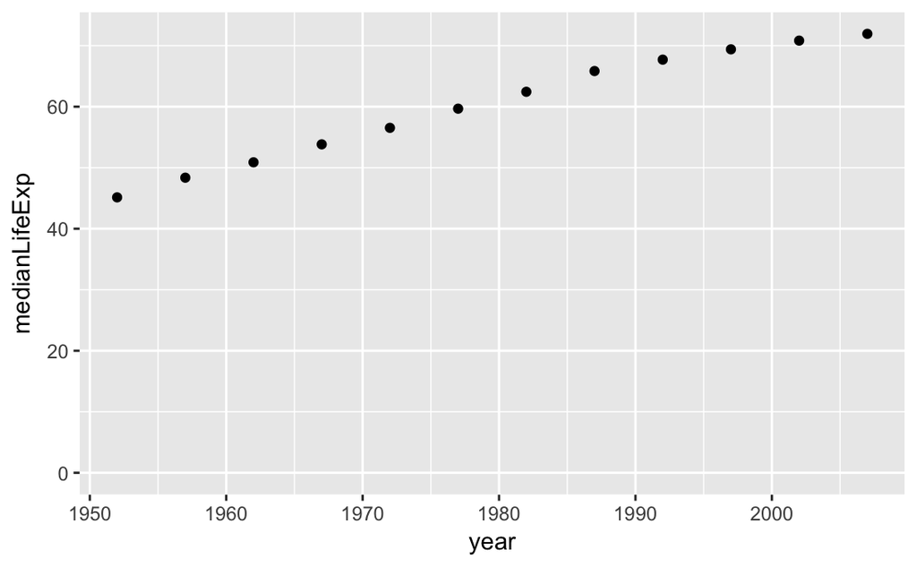

```r
ggplot(by_year, aes(x = year, y = medianLifeExp)) + geom_point() + expand_limits(y=0)
```

#### Combining multiple groups and colored plotting:

Tasks:

- Summarize the gapminder dataset by continent and year, finding the median GDP per capita (gdpPercap) within each and putting it into a column called medianGdpPercap. Use the assignment operator <- to save this summarized data as by_year_continent.
- Create a scatter plot showing the change in medianGdpPercap by continent over time. Use color to distinguish between continents, and be sure to add expand_limits(y = 0) so that the y-axis starts at zero.

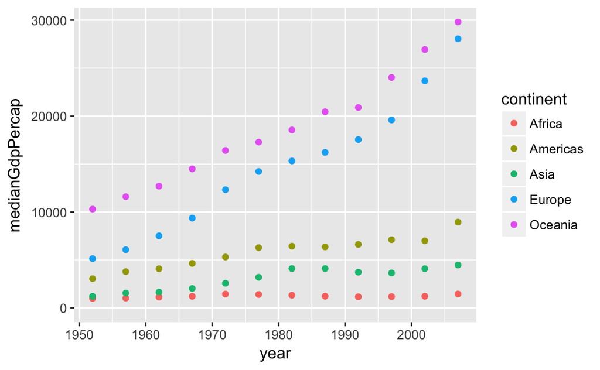

```r
by_year_continent <- gapminder %>%
  group_by(year, continent) %>%
  summarize(medianGdpPercap = median(gdpPercap))
ggplot(by_year_continent, aes(year, medianGdpPercap, color = continent)) + geom_point() + expand_limits(y=0)
```